# Application to change point detection problem

Although we developed SuSiE primarily with the goal of performing variable selection in highly sparse settings -- and, in particular, for genetic fine-mapping -- the approach also has considerable potential for application to other large-scale regression problems. Here we briefly illustrate this potential by applying it to a non-parametric regression problem that at first sight seems to be ill-suited to our approach.

Specifically we focus on the "change point detection problem", which does not involve strict sparsity, and the underlying correlation structure of the explanatory variables is very different from the "blocky" covariance structure of genetic data that SuSiE was designed for. Nonetheless, we will see that SuSiE performs well here despite this (partly due to its ability to capture non-sparse signals via Bayesian Model Averaging). Consider the non-parametric regression: $$y_t = \mu_t + e_t \quad t=1,\dots,T$$ where the goal is to estimate the underlying mean, $\mu_t$, under the assumption that it varies smoothly (or, more precisely, in a spatially-structured way) with $t$. One very simple way to capture spatial structure in $\mu$ is to model it as a (sparse) linear combination of step functions: $$\mu = Xb$$ where the $j$th column of $X$ is the step function with a step at $j$ ($j = 1,\dots,(T-1)$); that is $x_{tj}=0$ for $t<=j$ and 1 for $t>j$. The $j$th element of $b$ therefore determines the change in the mean $|\mu_j-\mu_{j+1}|$, and an assumption that $b$ is sparse encapsulates an assumption that $\mu$ is spatially structured (indeed, piecewise constant). This very simple approach is essentially [0th-order trend filtering](https://projecteuclid.org/euclid.aos/1395234979).

## SuSiE change point example

To illustrate the potential of SuSiE for change point estimation we applied it to a simple simulated example from the `DNAcopy` package.

```python
library("susieR")
library("DNAcopy")
library("changepoint")
```

The example comes from `?DNAcopy::segment` (note we changed this into a single problem (single chromosome) whereas the example was originally split into two chromosomes).

```python
set.seed(51)
genomdat <- rnorm(500, sd=0.2) +
rep(c(-0.2,0.1,1,-0.5,0.2,-0.5,0.1,-0.2),c(137,87,17,49,29,52,87,42))
chrom <- rep(1,500)
maploc <- c(1:500)
test2 <- DNAcopy::segment(CNA(genomdat, chrom, maploc))
```

```
Analyzing: Sample.1
```

```python
pdf("cp_truth.pdf", width=8, height=5, pointsize=16)
plot(test2)
dev.off()
```

**png:** 2

%preview cp_truth.pdf

> cp_truth.pdf (8.1 KiB):

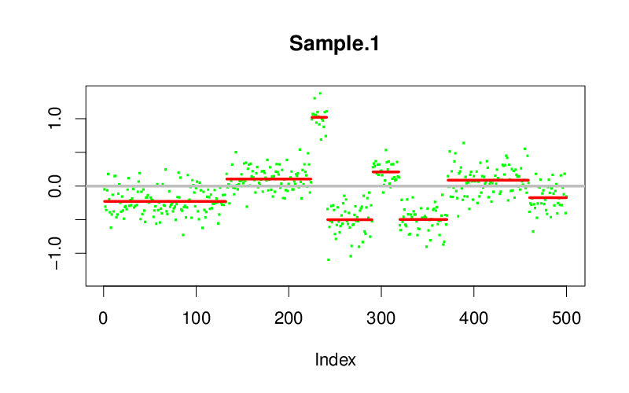

```python
%preview cp_truth.pdf -s png --dpi 100
```

We have implemented in `susieR` 0.6.0 a funciton `susie_trendfilter` which internally creates $X$ matrix with step functions in the columns to match input $y$. The algebra have been optimized to work on such trendfiltering matrices.

```python
genomdat.s = susieR::susie_trendfilter(genomdat,0)
```

```python
plot_cs = function(s){
  CS = s$sets$cs
  for(i in 1:length(CS)){
    rect(min(CS[[i]]),-5,max(CS[[i]])+1,5,col = rgb(1,0,0,alpha=0.5),border=NA)
  }
}
pdf("cp_susie_example.pdf", width=8, height=5, pointsize=16)
plot(genomdat,col=gray(0.5),ylab="y",xlab="",cex=0.65)
segments(x0=test2$output$loc.start,x1=test2$output$loc.end,y0=test2$output$seg.mean,col="blue",lwd=2)
abline(v=cumsum(c(137,87,17,49,29,52,87))) # changepoint locations
plot_cs(genomdat.s)
dev.off()
```

**png:** 2

%preview cp_susie_example.pdf

> cp_susie_example.pdf (8.4 KiB):

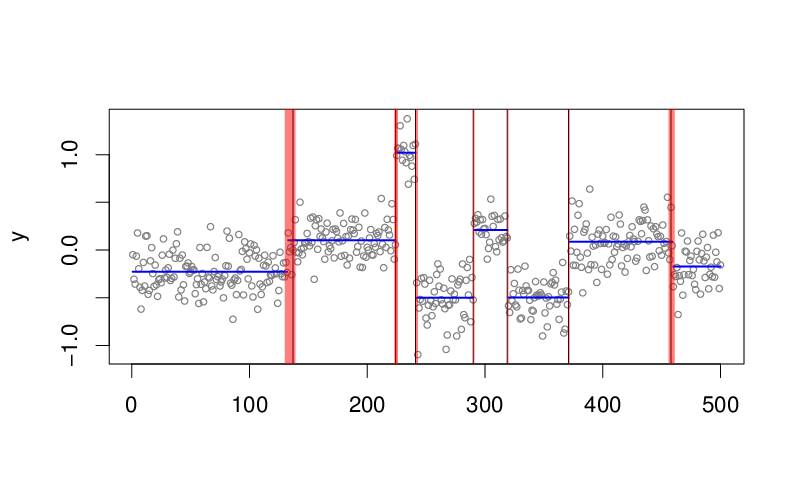

```python
%preview cp_susie_example.pdf -s png --dpi 100
```

## Convergence issue

We set up a simple simulated example with two change points very close together.

```python
set.seed(1)
x = rnorm(100)
x[50:51]=x[50:51]+8
x.s = susie_trendfilter(x,0,L=2,estimate_prior_variance=TRUE)
pdf("cp_susie_convergence_bad.pdf", width=8, height=5, pointsize=16)
plot(x,col=gray(0.5),ylab="y",xlab="",cex=0.65)
lines(predict(x.s),type="s",lwd=2)
dev.off()
```

**png:** 2

%preview cp_susie_convergence_bad.pdf

> cp_susie_convergence_bad.pdf (5.7 KiB):

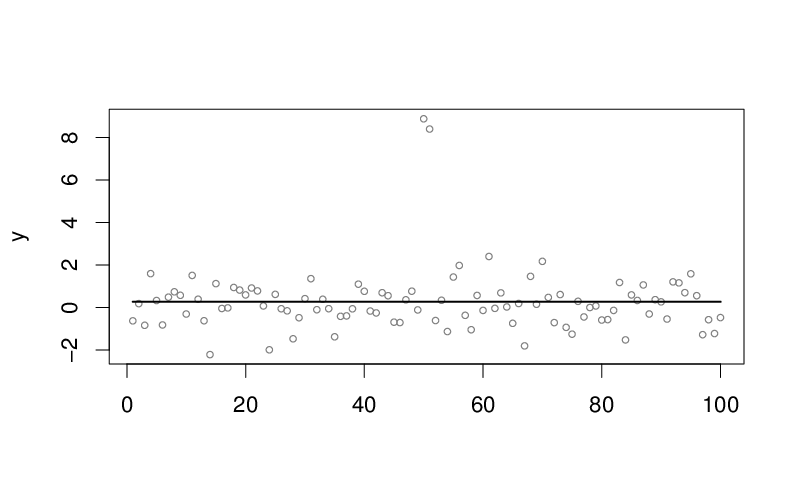

```python
%preview cp_susie_convergence_bad.pdf -s png --dpi 100
```

```python
susie_get_objective(x.s)
```

-181.835041124445

Now initialize at the "truth",

```python
s0 = susie_init_coef(c(49,51),coef_value = c(8,-8),p=100)
x.s2 = susie_trendfilter(x,0,s_init=s0,estimate_prior_variance=TRUE)
pdf("cp_susie_convergence_okay.pdf", width=8, height=5, pointsize=16)
plot(x,col=gray(0.5),ylab="y",xlab="", cex=0.65)
lines(predict(x.s2),col=2,type="s", lwd=2)
dev.off()
```

**png:** 2

%preview cp_susie_convergence_okay.pdf

> cp_susie_convergence_okay.pdf (5.7 KiB):

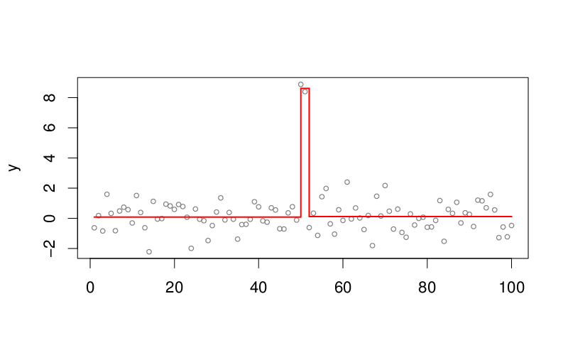

```python
%preview cp_susie_convergence_okay.pdf -s png --dpi 100
```

The objective is better compared to previous fit,

```python
susie_get_objective(x.s2)
```

-148.217576587086

## Figure for the manuscript

Putting these plots together,

```python
pdf("cp_susie.pdf", width=8, height=6, pointsize=16)
par(mfrow=c(2,1),mar=c(2,4,2,2), cex.axis=0.8)

plot(genomdat,col=gray(0.5), ylab="y", xlab="variable", cex=0.65)
segments(x0=test2$output$loc.start,x1=test2$output$loc.end,y0=test2$output$seg.mean,col="blue",lwd=2)
abline(v=cumsum(c(137,87,17,49,29,52,87))) # changepoint locations
plot_cs(genomdat.s)

plot(x,col=gray(0.5), ylab="y", xlab="variable", cex = 0.65)
lines(predict(x.s),type="s", lwd=2)
lines(predict(x.s2),col=2, type="s", lwd=2)
dev.off()
```

**png:** 2

%preview cp_susie.pdf

> cp_susie.pdf (10.6 KiB):

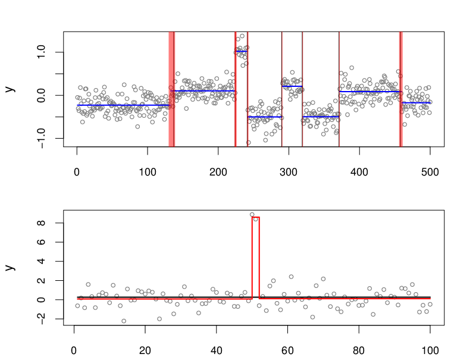

```python
%preview cp_susie.pdf -s png --dpi 100
```

```python
%sessioninfo
```

SoS

SoS Version

```
0.17.5
```

R

Kernel

```
ir
```

Language

```
R
```

© 2017-2018 authored by Gao Wang at Stephens Lab, The University of Chicago

Exported from [`manuscript_results/changepoint_example.ipynb`](http://github.com/stephenslab/susie-paper/blob/fe1be96c9ad6f4fab65c9f80929e0118e8487d8e/manuscript_results/changepoint_example.ipynb) committed by Gao Wang on Wed Dec 19 05:30:12 2018 [revision 3, fe1be96](http://github.com/stephenslab/susie-paper/commit/fe1be96c9ad6f4fab65c9f80929e0118e8487d8e)